# Statistics

```r
norm_check
```

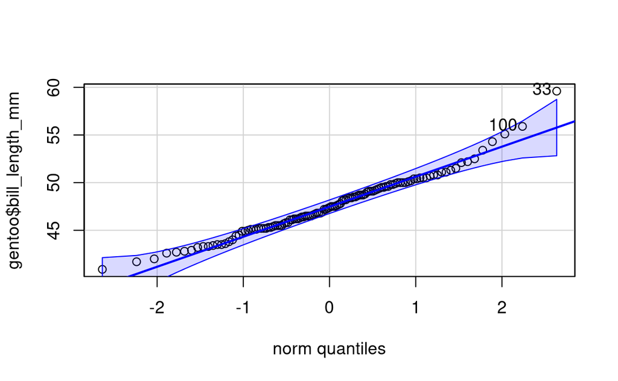

```r
library("car")
qqnormplot<- qqPlot(gentoo$bill_length_mm)
```

```r
qqnormplot
```

```
[1]  33 100
```

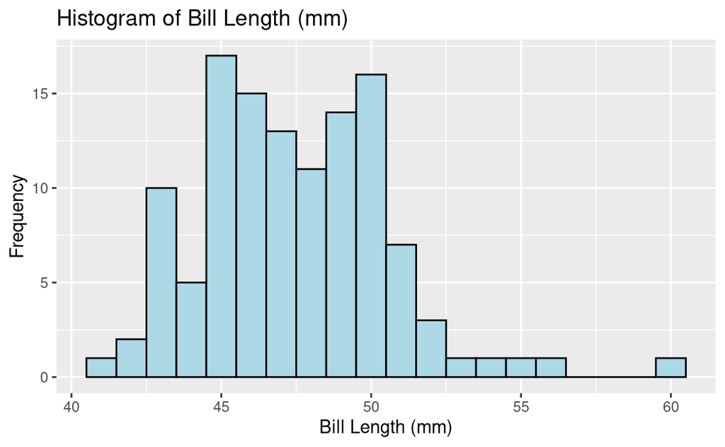

```r
library(performance)
check_normality(gentoo$bill_length_mm,sample.size=length(gentoo$bill_length_mm), main = "Y")
ggplot(gentoo, aes(x = bill_length_mm)) +
  geom_histogram(binwidth = 1, color = "black", fill = "lightblue") +
  labs(title = "Histogram of Bill Length (mm)", x = "Bill Length (mm)", y = "Frequency")
```

The rnorm() function in R generates a vector of random numbers sampled from a normal distribution. It requires three main arguments to define the characteristics of the distribution:`n` ,`mean` ,`sd`

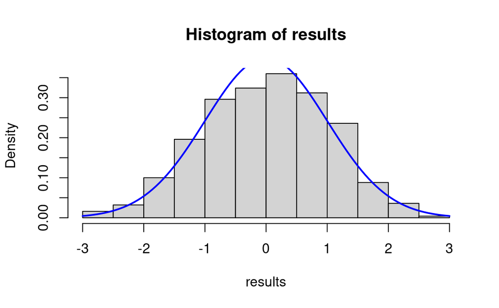

```r
#Example of Noemal distributed data
results = c();
mu = 0; sigma = 1
for(i in 1:500) {
 X = rnorm(100,mu,sigma) # generate random data
 results[i] = (mean(X) - mu)/(sigma/sqrt(100))
}
his_X <- hist(results,prob=T,xlim = c(-3,3))
his_X <- curve(dnorm(x, 0, 1), add = TRUE, col = "blue", lwd = 2)
```

```r
his_X
```

[output not shown]

[output cut: 26 more lines]

```
[1] 29 37
```

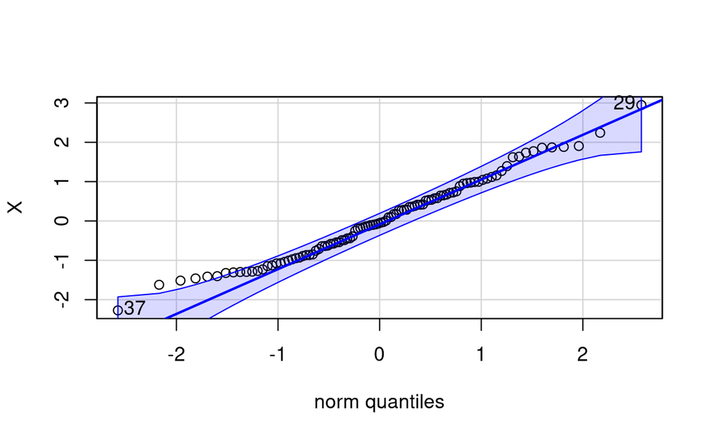

```r
qqPlot(X)
```

```r
check_normality(X,sample.size=100, main = "Y")
```

```
OK: raw appear as normally distributed (p = 0.168).
```

The `rnonnorm()` function in R generating a vector of random numbers sampled from a non-normal data with specified skewness and kurtosis using Fleishman’s Method.

```r
#Example of Non-Noemal distributed data

library(detectnorm)
nonnorm <- numeric(0)
for(i in 1:500) {
nonnorm<- rnonnorm(n = 100, mean = 0, sd = 1, skew = -1, kurt = 1)$dat}
summary(nonnorm)
```

```
    Min.  1st Qu.   Median     Mean  3rd Qu.     Max.
-2.51516 -0.83570  0.07980 -0.05383  0.83026  1.31070
```

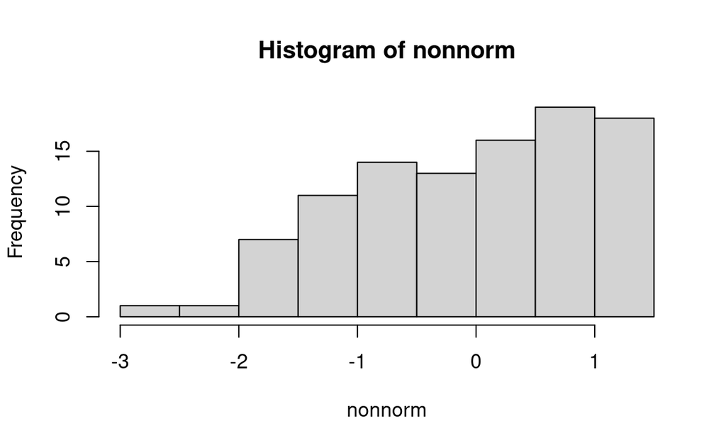

```r
hist_n<-hist(nonnorm)
```

```r
hist_n
```

```
$breaks
 [1] -3.0 -2.5 -2.0 -1.5 -1.0 -0.5  0.0  0.5  1.0  1.5

$counts
[1]  1  1  7 11 14 13 16 19 18

$density
[1] 0.02 0.02 0.14 0.22 0.28 0.26 0.32 0.38 0.36

$mids
[1] -2.75 -2.25 -1.75 -1.25 -0.75 -0.25  0.25  0.75  1.25

$xname
[1] "nonnorm"

$equidist
[1] TRUE

attr(,"class")
[1] "histogram"
```

```
[1] 33 77
```

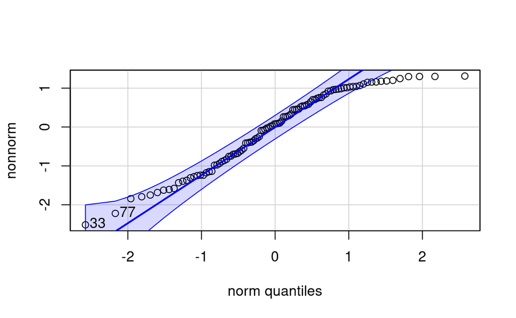

```r
qqPlot(nonnorm)
```

```r
check_normality(nonnorm, sample.size=100, main = "Y")
```

# The homogeneity of variance

```r
#To check the homogeneity of variance across different groups
leveneTest(bill_length_mm ~ sex, data = df)
```

```
Levene's Test for Homogeneity of Variance (center = median)
       Df F value  Pr(>F)
group   1  2.8244 0.09378 .
      331
---
Signif. codes:  0 ‘***’ 0.001 ‘**’ 0.01 ‘*’ 0.05 ‘.’ 0.1 ‘ ’ 1
```

```r
#p-value < 0.05: evidence of the unequal variances for the sample.
#Df: Degrees of freedom.
#F value: The test statistic for Levene's test.
#Pr(>F): The p-value associated with the test statistic.
```

Since the p-value (0.09378) of `leveneTest` is greater than 0.05, we do not reject the null hypothesis. This suggests that there is no strong evidence against the assumption of homogeneity of variances across `sex` based on Levene’s test.

# One Sample Proportion Test

```r
prop_sex<- table(df$sex)
prop_sex
```

```
female   male
   165    168
```

```r
prop.test(prop_sex,conf.level = 0.95)
```

```
    1-sample proportions test with continuity correction

data:  prop_sex, null probability 0.5
X-squared = 0.012012, df = 1, p-value = 0.9127
alternative hypothesis: true p is not equal to 0.5
95 percent confidence interval:
 0.4406707 0.5504259
sample estimates:
        p
0.4954955
```

```r
#X-squared: The test statistic for the chi-squared test.
#df: Degrees of freedom.
#Alternative hypothesis: Indicates whether the test is two-tailed.
#Confidence interval: Provides the 95% confidence interval for the true proportion p.
#Sample estimates: Provides the estimated proportion p from your sample.
```

The p-value (0.9127) of `prop.test` is much greater than 0.05, indicating that there is no significant evidence to reject the null hypothesis. Therefore, there is no significant difference between the observed proportions of females and males

# Student’s t-test

suitable when comparing means between two groups, under the assumption that the variances in both groups are equal.

```r
t.test(df$body_mass_g,df$flipper_length_mm,conf.level = 0.99,var.equal = TRUE)
```

```
    Two Sample t-test

data:  df$body_mass_g and df$flipper_length_mm
t = 90.775, df = 664, p-value < 2.2e-16
alternative hypothesis: true difference in means is not equal to 0
99 percent confidence interval:
 3892.085 4120.095
sample estimates:
mean of x mean of y
 4207.057   200.967
```

```r
#t: The t-statistic for the test.
#df: Degrees of freedom.
#p-value: The probability of observing a test statistic at least as extreme as the one observed, under the null hypothesis that there is no difference between the means of the two groups.
#Alternative hypothesis: Indicates whether the test is two-tailed (true difference in means is not equal to 0), which is typical for this test.
#Confidence interval: Provides the 99% confidence interval for the difference in means between the two groups.
#Sample estimates: Provides the sample means (mean of x for df$body_mass_g and mean of y for df$flipper_length_mm).
```

The p-value is very small (less than 2.2e-16), indicating strong evidence against the null hypothesis. Therefore, based on this test, there is a significant difference between the mean body mass and mean flipper length in the sample. The confidence interval suggests that we are 99% confident that the true difference in means lies between 3892.085 and 4120.095. This analysis indicates that the body mass and flipper length are significantly different in the sample, based on the two-sample t-test. # Chi-Squared Test

```r
#Contingency Table
str(df)
```

```
tibble [333 × 8] (S3: tbl_df/tbl/data.frame)
 $ species          : Factor w/ 3 levels "Adelie","Chinstrap",..: 1 1 1 1 1 1 1 1 1 1 ...
 $ island           : Factor w/ 3 levels "Biscoe","Dream",..: 3 3 3 3 3 3 3 3 3 3 ...
 $ bill_length_mm   : num [1:333] 39.1 39.5 40.3 36.7 39.3 38.9 39.2 41.1 38.6 34.6 ...
 $ bill_depth_mm    : num [1:333] 18.7 17.4 18 19.3 20.6 17.8 19.6 17.6 21.2 21.1 ...
 $ flipper_length_mm: int [1:333] 181 186 195 193 190 181 195 182 191 198 ...
 $ body_mass_g      : int [1:333] 3750 3800 3250 3450 3650 3625 4675 3200 3800 4400 ...
 $ sex              : Factor w/ 2 levels "female","male": 2 1 1 1 2 1 2 1 2 2 ...
 $ year             : Date[1:333], format: "1975-07-01" ...
```

```r
Sp_IS_tb <- table( Species = df$species, Island = df$island )
Sp_IS_tb <- addmargins( Sp_IS_tb )
Sp_IS_tb
```

```
           Island
Species     Biscoe Dream Torgersen Sum
  Adelie        44    55        47 146
  Chinstrap      0    68         0  68
  Gentoo       119     0         0 119
  Sum          163   123        47 333
```

```r
chisq.test( Sp_IS_tb )
```

```
    Pearson's Chi-squared test

data:  Sp_IS_tb
X-squared = 284.59, df = 9, p-value < 2.2e-16
```

```r
#X-squared: The test statistic for the Chi-squared test.
#df: Degrees of freedom.
#p-value: The probability of observing a test statistic at #least as extreme as the one observed, under the null #hypothesis that there is no association between the #variables.
#Null hypothesis: Typically, the null hypothesis is that #there is no association between the variables (independence #or no difference from expected frequencies).
```

The p-value is very small (less than 2.2e-16), suggesting strong evidence against the null hypothesis. Therefore, based on this test, there is a significant association or difference in frequencies across the categories in Sp_IS_tb. In summary, this Chi-squared test indicates that there is a significant relationship or difference among the species and islands, based on the observed frequencies. If the sample size is small, we have to use Fisher’s Exact Test: ## Fisher’s Exact Test It is used to determine if there are nonrandom associations between two categorical variables.

```r
fisher.test(df$island,df$species)
```

[output not shown]

#Correlation Test

```r
cor(df$bill_length_mm,df$body_mass_g,method = "pearson")
```

```
[1] 0.5894511
```

```r
cor(df$bill_length_mm,df$body_mass_g,method = "kendall")
```

```
[1] 0.4277598
```

```r
cor(df$bill_length_mm,df$body_mass_g,method = "spearman")
```

```
[1] 0.5764804
```

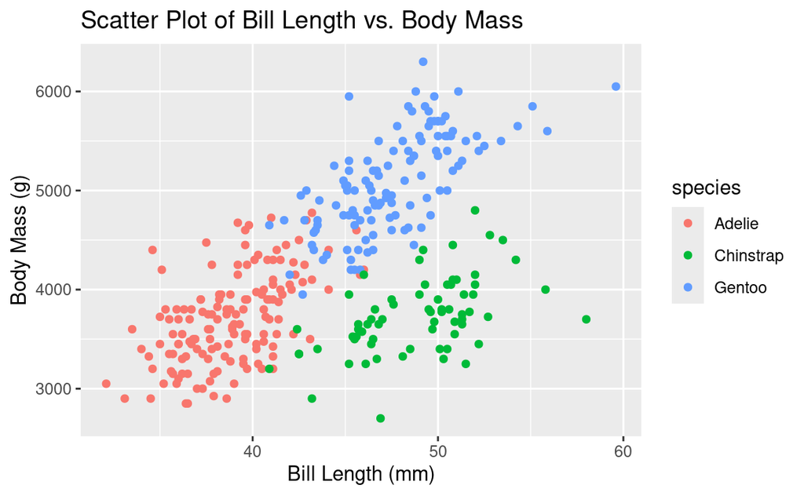

```r
#scatter plots for bill length vs. bill depth
ggplot(df, aes(x = bill_length_mm, y = body_mass_g, color = species)) +
  geom_point() +
  labs(title = "Scatter Plot of Bill Length vs. Body Mass", x = "Bill Length (mm)", y = "Body Mass (g)")
```

```r
cor(df[,c(3:6)],method = "pearson")
```

```
                  bill_length_mm bill_depth_mm
bill_length_mm         1.0000000    -0.2286256
bill_depth_mm         -0.2286256     1.0000000
flipper_length_mm      0.6530956    -0.5777917
body_mass_g            0.5894511    -0.4720157
                  flipper_length_mm body_mass_g
bill_length_mm            0.6530956   0.5894511
bill_depth_mm            -0.5777917  -0.4720157
flipper_length_mm         1.0000000   0.8729789
body_mass_g               0.8729789   1.0000000
```

```r
cor(df[,c(3:6)],method = "spearman")
```

```
                  bill_length_mm bill_depth_mm
bill_length_mm         1.0000000    -0.2138594
bill_depth_mm         -0.2138594     1.0000000
flipper_length_mm      0.6697536    -0.5173170
body_mass_g            0.5764804    -0.4292826
                  flipper_length_mm body_mass_g
bill_length_mm            0.6697536   0.5764804
bill_depth_mm            -0.5173170  -0.4292826
flipper_length_mm         1.0000000   0.8403902
body_mass_g               0.8403902   1.0000000
```

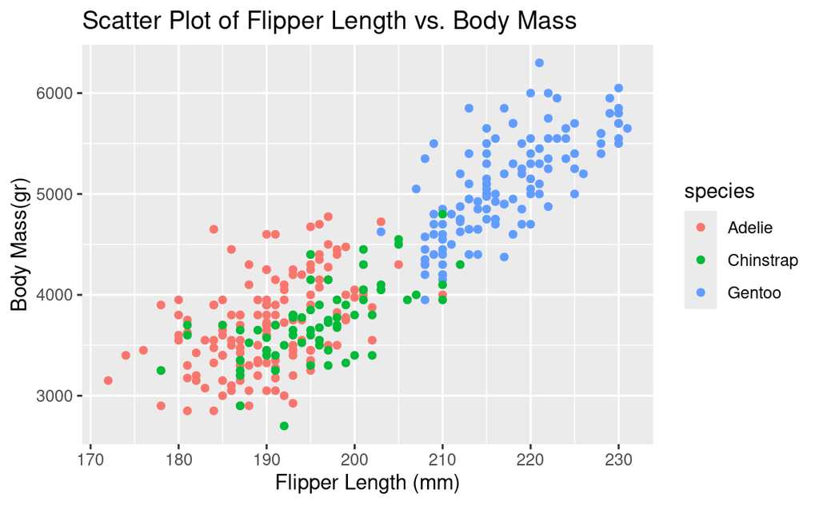

```r
#scatter plots for flipper length vs. body mass
ggplot(df, aes(x = flipper_length_mm, y = body_mass_g, color = species)) +
  geom_point() +
  labs(title = "Scatter Plot of Flipper Length vs. Body Mass", x = "Flipper Length (mm)", y = "Body Mass(gr)")
```

# ANOVA

In situations involving two variables, the setup is straightforward. The response variable is positioned on the left-hand side, while the predictor variable is on the right-hand side:

response ∼ predictor (when two variables)

This notation indicates the relationship where the response variable, typically the dependent variable of interest, is modeled as a function of the predictor variable, which serves as the independent variable.

```r
one_way <- aov(body_mass_g ~ species, data=df)
summary(one_way)
```

```
             Df    Sum Sq  Mean Sq F value Pr(>F)
species       2 145190219 72595110   341.9 <2e-16 ***
Residuals   330  70069447   212332
---
Signif. codes:  0 ‘***’ 0.001 ‘**’ 0.01 ‘*’ 0.05 ‘.’ 0.1 ‘ ’ 1
```

```r
#Df (Degrees of Freedom): This represents the degrees of #freedom associated with the model (species) and the #residuals (error).
#Sum Sq (Sum of Squares): This is a measure of the variance #explained by the model (species) and the residuals.
#Mean Sq (Mean Sum of Squares): This is the sum of squares #divided by its degrees of freedom, representing the #variance estimate.
#F value: This is the test statistic for the ANOVA test, #which compares the variance between groups (due to species) #to the variance within groups (residual variance).
#Pr(>F): This is the p-value associated with the F #statistic. It indicates the probability of observing an F #value as extreme or more extreme than the one observed, #under the null hypothesis that there is no difference #between group means.
```

The one-way ANOVA indicates that there is a statistically significant difference in body mass among the different species of penguins. Specifically, the F-statistic of 341.9 with a very low p-value (<2e-16) suggests that at least one species differs significantly in body mass from the others.

##TukeyHSD To do pairwise comparisons of means among the species based on the results of one-way ANOVA

```r
#Post-hoc tests take into account that multiple tests are done
TuHSD<- TukeyHSD(one_way)
TuHSD
```

```
  Tukey multiple comparisons of means
    95% family-wise confidence level

Fit: aov(formula = body_mass_g ~ species, data = df)

$species
                       diff       lwr       upr    p adj
Chinstrap-Adelie   26.92385 -132.3528  186.2005 0.916431
Gentoo-Adelie    1386.27259 1252.2897 1520.2554 0.000000
Gentoo-Chinstrap 1359.34874 1194.4304 1524.2671 0.000000
```

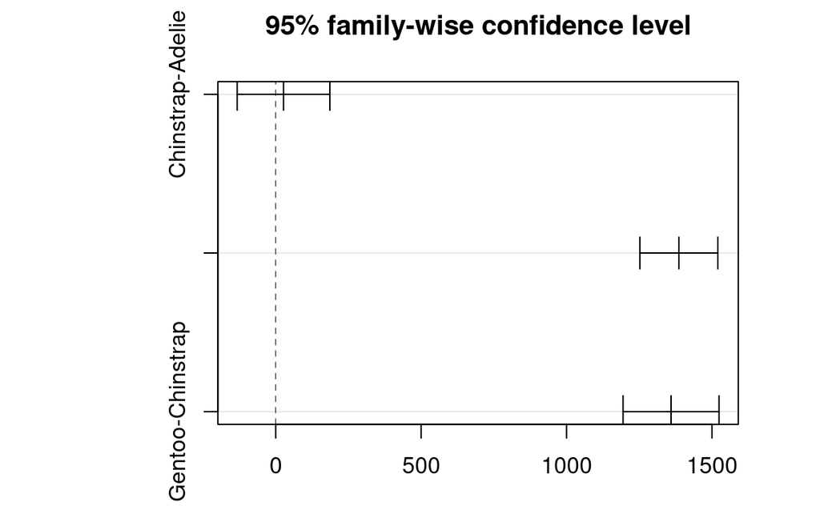

```r
library(multcomp)
glht_test <- glht(one_way,
  linfct = mcp(species = "Tukey")
)
par(mar = c(3, 8, 3, 3))
Tu<- plot(TuHSD)
```

```r
Tu
```

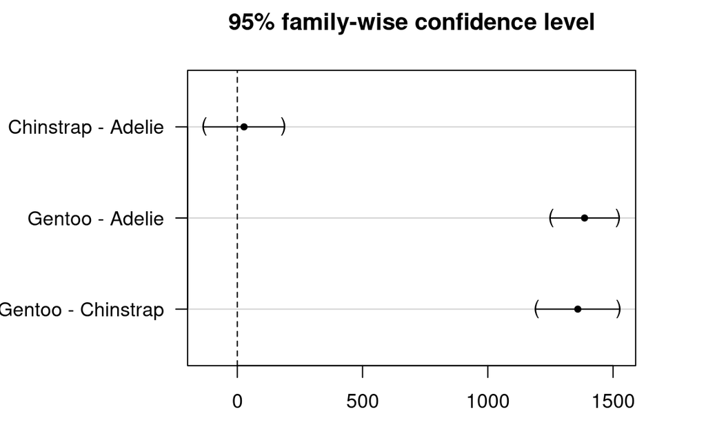

```r
plot(glht_test)
```

```r
#Adjusted p-value (p adj): This value adjusts for multiple #comparisons (family-wise error rate) using methods such as #Tukey's HSD to account for the increased risk of Type I #errors (false positives) when performing multiple tests.
#Confidence Interval (CI): Indicates the range within which #the true difference in means between groups is likely to #fall.
#Significance: Comparisons with adjusted p-values below your #chosen significance level (e.g., 0.05) suggest significant #differences between groups. In your results, Gentoo #penguins significantly differ in body mass compared to both #Adelie and Chinstrap penguins.
```

```r
two_way <- aov(bill_depth_mm ~ sex + species, data=df)
summary(two_way)
```

```
             Df Sum Sq Mean Sq F value Pr(>F)
sex           1  178.8   178.8   257.8 <2e-16 ***
species       2  880.5   440.2   634.8 <2e-16 ***
Residuals   329  228.2     0.7
---
Signif. codes:  0 ‘***’ 0.001 ‘**’ 0.01 ‘*’ 0.05 ‘.’ 0.1 ‘ ’ 1
```

```r
TukeyHSD(two_way, which = "species")
```

```
  Tukey multiple comparisons of means
    95% family-wise confidence level

Fit: aov(formula = bill_depth_mm ~ sex + species, data = df)

$species
                        diff        lwr        upr     p adj
Chinstrap-Adelie  0.07332796 -0.2145367  0.3611926 0.8203452
Gentoo-Adelie    -3.36909578 -3.6112463 -3.1269453 0.0000000
Gentoo-Chinstrap -3.44242374 -3.7404848 -3.1443627 0.0000000
```

```r
kruskal.test(bill_length_mm ~ species,data = df)
```

```
    Kruskal-Wallis rank sum test

data:  bill_length_mm by species
Kruskal-Wallis chi-squared = 236.9, df = 2, p-value <
2.2e-16
```

```r
library(FSA)
dunnTest(bill_length_mm ~ species,data = df,method = "holm")
```

```
Dunn (1964) Kruskal-Wallis multiple comparison
  p-values adjusted with the Holm method.
```

| Comparison | Z | P.unadj | P.adj |
| --- | --- | --- | --- |
| Adelie - Chinstrap | -12.624802 | 1.541296e-36 | 3.082592e-36 |
| Adelie - Gentoo | -12.920828 | 3.434249e-38 | 1.030275e-37 |
| Chinstrap - Gentoo | 1.695791 | 8.992553e-02 | 8.992553e-02 |

## More than two variable

When dealing with more than two predictor variables, there are several notations commonly used in this context:

For instance Y, X1 and X2 are variables:

- Y∼X1: Indicates that Y is modeled by X1.
- Y∼X1+X2: Indicates that Y is modeled using both X1 and X2, akin to multiple regression.
- Y∼X1∗X2: Indicates that Y is modeled using X1, X2, and their interaction X1×X2.
- Y∼(X1+X2)^2: Represents two-way interactions between X1 and X2. Note that typical mathematical powers apply here.
- Y∼X1+I((X2^2): Indicates Y is modeled by X1 and X2^2, where the I function is used to encapsulate non-standard mathematical expressions.
- Y∼X1∣X2: Denotes that Y is modeled by X1 conditioned on X2.

#Principal Component Analysis Let’s take a look at the correlation matrix

```r
library(corrr)
cor_df <- df %>%
  dplyr::select(body_mass_g, ends_with("_mm")) %>%
  correlate() %>%
  rearrange()
```

```
Correlation computed with
• Method: 'pearson'
• Missing treated using: 'pairwise.complete.obs'
```

```r
cor_df
```

| term | flipper_length_mm | body_mass_g | bill_length_mm | bill_depth_mm |
| --- | --- | --- | --- | --- |
| flipper_length_mm | NA | 0.8729789 | 0.6530956 | -0.5777917 |
| body_mass_g | 0.8729789 | NA | 0.5894511 | -0.4720157 |
| bill_length_mm | 0.6530956 | 0.5894511 | NA | -0.2286256 |
| bill_depth_mm | -0.5777917 | -0.4720157 | -0.2286256 | NA |

Previously we used `cor()` to illustrate th correlation between features. There is a strong correlation observed between body mass and flipper length in the dataset. However, the bill variables do not show similarly strong correlations with other variables in the dataset.

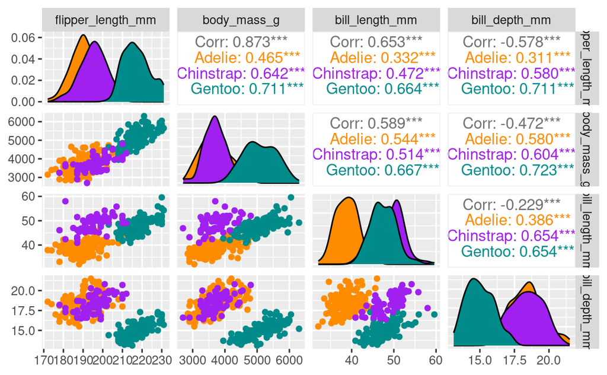

```r
library(dplyr)
df %>%
  dplyr::select(species, body_mass_g, ends_with("_mm")) %>%
  GGally::ggpairs(aes(color = species),
          columns = c("flipper_length_mm", "body_mass_g",
                      "bill_length_mm", "bill_depth_mm")) +
  scale_colour_manual(values = c("darkorange","purple","cyan4")) +
  scale_fill_manual(values = c("darkorange","purple","cyan4"))
```

we will applying some preprocessing steps which make the dataset ready for PCA:

1- Eliminate any missing values (NA values).(done) 2- Center all predictors to have a mean of zero. 3- Scale all predictors to have unit variance.

```r
library(recipes)
recipe_df <-
  recipe(~., data = df) %>%
  update_role(species, island, sex, year, new_role = "id") %>%
  step_naomit(all_predictors()) %>%
  step_normalize(all_predictors()) %>%
  step_pca(all_predictors(), id = "pca") %>%
  prep()

pca_df <-
  recipe_df %>%
  tidy(id = "pca")

pca_df
```

| terms | value | component | id |
| --- | --- | --- | --- |
| bill_length_mm | 0.45375317 | PC1 | pca |
| bill_depth_mm | -0.39904723 | PC1 | pca |
| flipper_length_mm | 0.57682500 | PC1 | pca |
| body_mass_g | 0.54967471 | PC1 | pca |
| bill_length_mm | -0.60019490 | PC2 | pca |
| bill_depth_mm | -0.79616951 | PC2 | pca |
| flipper_length_mm | -0.00578817 | PC2 | pca |
| body_mass_g | -0.07646366 | PC2 | pca |
| bill_length_mm | -0.64249509 | PC3 | pca |
| bill_depth_mm | 0.42580043 | PC3 | pca |

[output cut: 6 more lines]

For each component, the value indicates the linear combination of weights assigned to each variable contributing to that component.

```r
prcomp_df <- df %>%
  dplyr::select(body_mass_g, ends_with("_mm")) %>%
  tidyr::drop_na() %>%
  scale() %>%
  prcomp() %>%  #Performs a principal components analysis on the given data matrix and returns the results as an object of class prcomp.
  .$rotation
prcomp_df
```

```
                         PC1        PC2        PC3        PC4
body_mass_g        0.5496747 0.07646366 -0.5917374 -0.5846861
bill_length_mm     0.4537532 0.60019490  0.6424951 -0.1451695
bill_depth_mm     -0.3990472 0.79616951 -0.4258004  0.1599044
flipper_length_mm  0.5768250 0.00578817 -0.2360952  0.7819837
```

A tidy representation achieved using the above code.

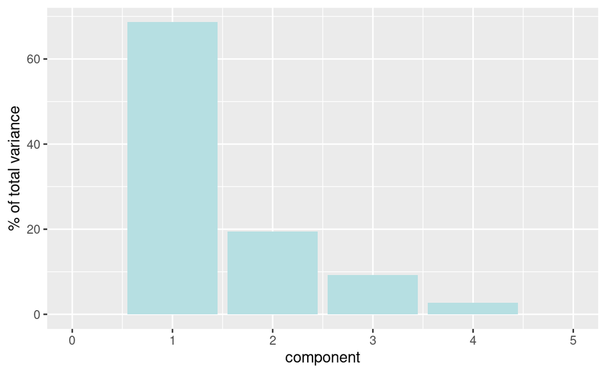

```r
#To examine how much variance each component accounts for:
recipe_df %>%
  tidy(id = "pca", type = "variance") %>%
  dplyr::filter(terms == "percent variance") %>%
  ggplot(aes(x = component, y = value)) +
  geom_col(fill = "#b6dfe2") +
  xlim(c(0, 5)) +
  ylab("% of total variance")
```

To plot the loadings by principal component, we can use a bar plot visualization method.

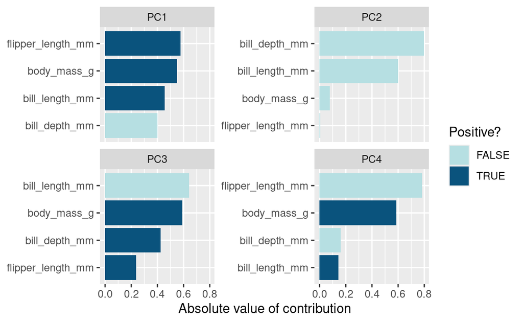

```r
pca_df %>%
  mutate(terms = tidytext::reorder_within(terms,
                                          abs(value),
                                          component)) %>%
  ggplot(aes(abs(value), terms, fill = value > 0)) +
  geom_col() +
  facet_wrap(~component, scales = "free_y") +
  tidytext::scale_y_reordered() +
  scale_fill_manual(values = c("#b6dfe2", "#0A537D")) +
  labs(
    x = "Absolute value of contribution",
    y = NULL, fill = "Positive?"
  )
```

To plot the data in a wide format, you can reshape it accordingly.

```r
pca_wider <- pca_df %>%
  tidyr::pivot_wider(names_from = component, id_cols = terms)
```